# 2. Discretized Non-negative Tri-Matrix Factorization (`dNMTF`)

Koki Tsuyuzaki

Laboratory for Bioinformatics Research, RIKEN Center for Biosystems Dynamics Research  
k.t.the-answer@hotmail.co.jp

2024-05-11

# Introduction

In this vignette, we consider approximating a binary or non-negative matrix as a product of three non-negative low-rank matrices (a.k.a., factor matrices).

Test data is available from `toyModel`.

```r
library("dcTensor")
X <- dcTensor::toyModel("dNMF")
```

You will see that there are five blocks in the data matrix as follows.

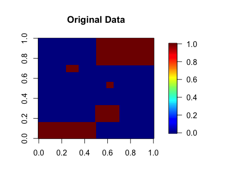

```r
suppressMessages(library("fields"))
image.plot(X, main="Original Data", legend.mar=8)
```

# Binary Matrix Tri-Factorization (BMTF)

Here, we consider the approximation of a binary data matrix $X$ ($N \times M$) as a matrix product of $U$ ($N \times J1$), $S$ ($J1 \times J2$), and $V$ ($M \times J2$):

$$X \approx U S V' \ \mathrm{s.t.}\ U,V \in \{0,1\}, S \geq 0$$

Here, we call this Binary Matrix Tri-Factorization (BMTF). BMTF is based on Non-negative Matrix Tri-Factorization (NMTF (Copar e2019; Long 2005; Ding 2006)) and Binary Matrix Factorization (BMF (Zhang 2007)). For the details of NMTF, see also `NMTF` function of nnTensor package.

## Basic Usage

In BMTF, two rank parameters $J1$ ($\leq N$) and $J2$ ($\leq M)$) is needed to be set in advance. Other settings such as the number of iterations (`num.iter`) or factorization algorithm (`algorithm`) are also available. For the details of arguments of dNMTF, see `?dNMTF`. After the calculation, various objects are returned by `dNMTF`.

```r
set.seed(123456)
out_BMTF <- dNMTF(X, Bin_U=10, Bin_V=10, rank=c(5,5))
str(out_BMTF, 2)
```

```
## List of 8
##  $ U            : num [1:100, 1:5] 0.124 0.124 0.124 0.124 0.124 ...
##  $ S            : num [1:5, 1:5] 9.54e-15 7.71e-02 7.65e-01 4.55 3.01 ...
##  $ V            : num [1:300, 1:5] 9.80e-08 2.12e-13 1.36e-56 1.07e-07 1.34e-11 ...
##  $ rank         : num [1:2] 5 5
##  $ RecError     : Named num [1:101] 1.00e-09 6.99e+01 6.59e+01 6.35e+01 6.19e+01 ...
##   ..- attr(*, "names")= chr [1:101] "offset" "1" "2" "3" ...
##  $ TrainRecError: Named num [1:101] 1.00e-09 6.99e+01 6.59e+01 6.35e+01 6.19e+01 ...
##   ..- attr(*, "names")= chr [1:101] "offset" "1" "2" "3" ...
##  $ TestRecError : Named num [1:101] 1e-09 0e+00 0e+00 0e+00 0e+00 0e+00 0e+00 0e+00 0e+00 0e+00 ...
##   ..- attr(*, "names")= chr [1:101] "offset" "1" "2" "3" ...
##  $ RelChange    : Named num [1:101] 1.00e-09 7.22 6.06e-02 3.89e-02 2.46e-02 ...
##   ..- attr(*, "names")= chr [1:101] "offset" "1" "2" "3" ...
```

The reconstruction error (`RecError`) and relative error (`RelChange`, the amount of change from the reconstruction error in the previous step) can be used to diagnose whether the calculation is converged or not.

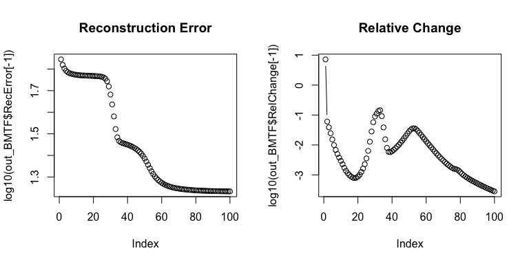

```r
layout(t(1:2))
plot(log10(out_BMTF$RecError[-1]), type="b", main="Reconstruction Error")
plot(log10(out_BMTF$RelChange[-1]), type="b", main="Relative Change")
```

The product of $U$, $S$, and $V$ shows whether the original data is well-recovered by `dNMTF`.

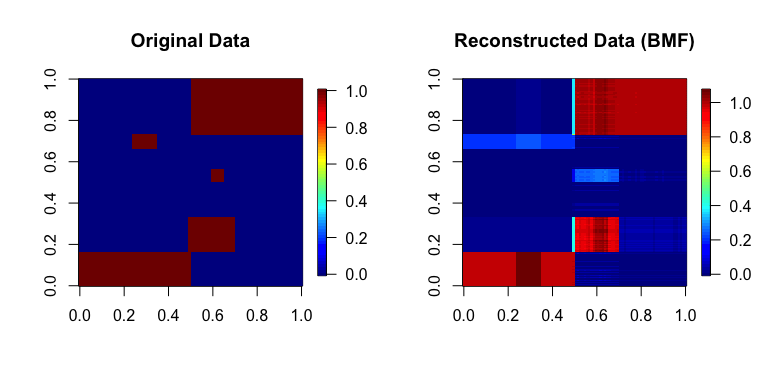

```r
recX <- out_BMTF$U %*% out_BMTF$S %*% t(out_BMTF$V)
layout(t(1:2))
image.plot(X, main="Original Data", legend.mar=8)
image.plot(recX, main="Reconstructed Data (BMF)", legend.mar=8)
```

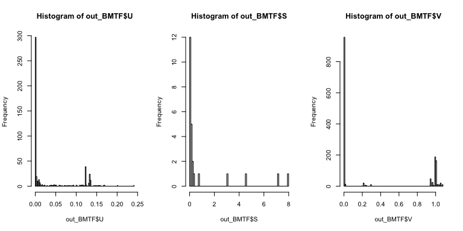

```r
layout(t(1:3))
hist(out_BMTF$U, breaks=100)
hist(out_BMTF$S, breaks=100)
hist(out_BMTF$V, breaks=100)
```

Note that these factor matrices do not always take the values of 0 and 1 completely. This is because the binarization in BMTF is based on the regularization to softly set the values as close to {0,1} as possible, and is not a hard binarization.

```r
out_BMTF$U[1:3,1:3]
```

```
##           [,1]         [,2]         [,3]
## [1,] 0.1238387 2.015980e-45 8.933262e-20
## [2,] 0.1238387 3.694257e-44 5.997028e-20
## [3,] 0.1238387 3.067534e-44 7.937174e-19
```

```r
out_BMTF$S
```

```
##              [,1]         [,2]         [,3]        [,4]         [,5]
## [1,] 9.535194e-15 7.902857e+00 1.213441e-40 0.006942176 8.308241e-06
## [2,] 7.707013e-02 4.897875e-28 7.171875e+00 0.001055494 1.150494e-01
## [3,] 7.649903e-01 8.425523e-34 2.629017e-01 0.021129672 3.997469e-01
## [4,] 4.546750e+00 1.047616e-15 8.178169e-02 0.173047727 1.173014e-01
## [5,] 3.014648e+00 3.017382e-31 2.199562e-01 0.100951552 1.204483e-01
```

```r
out_BMTF$V[1:3,1:3]
```

```
##              [,1]     [,2]         [,3]
## [1,] 9.798525e-08 1.002167 7.419010e-10
## [2,] 2.121454e-13 1.002167 6.227816e-12
## [3,] 1.362156e-56 1.001178 4.707794e-72
```

If you want to get the {0,1} values, use the `round` function as below:

```r
round(out_BMTF$U[1:3,1:3], 0)
```

```
##      [,1] [,2] [,3]
## [1,]    0    0    0
## [2,]    0    0    0
## [3,]    0    0    0
```

```r
round(out_BMTF$S, 0)
```

```
##      [,1] [,2] [,3] [,4] [,5]
## [1,]    0    8    0    0    0
## [2,]    0    0    7    0    0
## [3,]    1    0    0    0    0
## [4,]    5    0    0    0    0
## [5,]    3    0    0    0    0
```

```r
round(out_BMTF$V[1:3,1:3], 0)
```

```
##      [,1] [,2] [,3]
## [1,]    0    1    0
## [2,]    0    1    0
## [3,]    0    1    0
```

# Semi-Binary Matrix Tri-Factorization (SBMTF)

Next, we consider the approximation of a non-negative data matrix $X$ ($N \times M$) as the matrix product of binary matrix $U$ ($N \times J1$) and non-negative matrices, $S$ ($J1 \times J2$) and $V$ ($M \times J2$):

$$X \approx U S V' \ \mathrm{s.t.}\ U \in \{0,1\}, S, V \geq 0$$

Here, we define this formalization as Semi-Binary Matrix Tri-Factorization (SBMTF). SBMTF can capture discrete patterns from a non-negative matrix.

To demonstrate SBMTF, next we use a non-negative matrix from the `nnTensor` package.

```r
suppressMessages(library("nnTensor"))
X2 <- nnTensor::toyModel("NMF")
```

You will see that there are five blocks in the data matrix as follows.

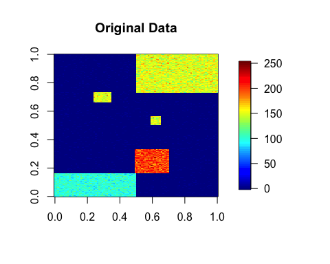

```r
image.plot(X2, main="Original Data", legend.mar=8)
```

## Basic Usage

Switching from BMTF to SBMTF is quite easy; SBMTF is achieved by specifying the binary regularization parameter as a large value like below:

```r
set.seed(123456)
out_SBMTF <- dNMTF(X2, Bin_U=1E+6, rank=c(5,5))
str(out_SBMTF, 2)
```

```
## List of 8
##  $ U            : num [1:100, 1:5] 0.977 0.983 0.985 0.987 0.975 ...
##  $ S            : num [1:5, 1:5] 0.000028 0.988919 0.200886 0.101142 0.119332 ...
##  $ V            : num [1:300, 1:5] 1.60e-10 2.01e-10 7.10e-10 4.99e-09 2.69e-11 ...
##  $ rank         : num [1:2] 5 5
##  $ RecError     : Named num [1:101] 1.00e-09 1.02e+04 9.64e+03 9.10e+03 8.67e+03 ...
##   ..- attr(*, "names")= chr [1:101] "offset" "1" "2" "3" ...
##  $ TrainRecError: Named num [1:101] 1.00e-09 1.02e+04 9.64e+03 9.10e+03 8.67e+03 ...
##   ..- attr(*, "names")= chr [1:101] "offset" "1" "2" "3" ...
##  $ TestRecError : Named num [1:101] 1e-09 0e+00 0e+00 0e+00 0e+00 0e+00 0e+00 0e+00 0e+00 0e+00 ...
##   ..- attr(*, "names")= chr [1:101] "offset" "1" "2" "3" ...
##  $ RelChange    : Named num [1:101] 1.00e-09 2.35e-01 6.25e-02 5.94e-02 4.95e-02 ...
##   ..- attr(*, "names")= chr [1:101] "offset" "1" "2" "3" ...
```

`RecError` and `RelChange` can be used to diagnose whether the calculation is converged or not.

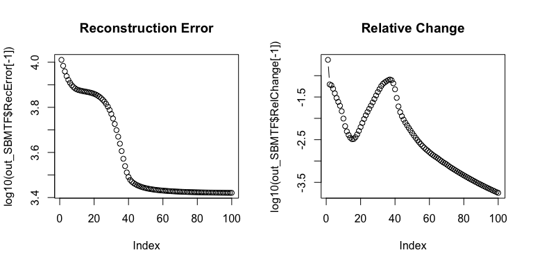

```r
layout(t(1:2))
plot(log10(out_SBMTF$RecError[-1]), type="b", main="Reconstruction Error")
plot(log10(out_SBMTF$RelChange[-1]), type="b", main="Relative Change")
```

The product of $U$, $S$, and $V$ shows whether the original data is well-recovered by `dNMTF`.

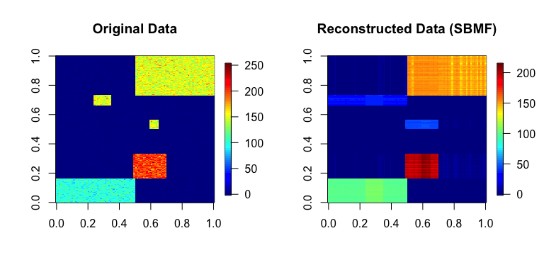

```r
recX2 <- out_SBMTF$U %*% out_SBMTF$S %*% t(out_SBMTF$V)
layout(t(1:2))
image.plot(X2, main="Original Data", legend.mar=8)
image.plot(recX2, main="Reconstructed Data (SBMF)", legend.mar=8)
```

The histograms of $U$, $S$, and $V$ show that $U$ looks binary but $S$ and $V$ do not.

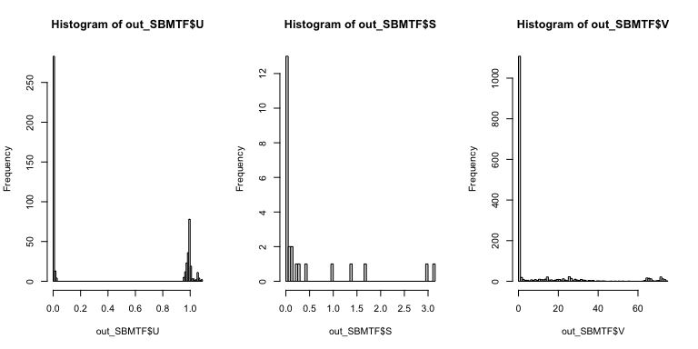

```r
layout(t(1:3))
hist(out_SBMTF$U, breaks=100)
hist(out_SBMTF$S, breaks=100)
hist(out_SBMTF$V, breaks=100)
```

# Semi-Ternary Matrix Tri-Factorization (STMTF)

Finally, we expand the binary regularization to ternary regularization to take {0,1,2} values as below:

$$X \approx U S V' \ \mathrm{s.t.}\ U \in \{0,1,2\}, S, V \geq 0,$$
where $X$ ($N \times M$) is a non-negative data matrix, $U$ ($N \times J1$) is a ternary matrix, and $S$ ($J1 \times J2$) and $V$ ($M \times J2$) are non-negative matrices.

## Basic Usage

STMTF is achieved by specifying the ternary regularization parameter as a large value like the below:

```r
set.seed(123456)
out_STMTF <- dNMTF(X2, Ter_U=1E+5, rank=c(5,5))
str(out_STMTF, 2)
```

```
## List of 8
##  $ U            : num [1:100, 1:5] 0.963 0.972 0.976 0.98 0.959 ...
##  $ S            : num [1:5, 1:5] 0.000277 0.86879 0.376385 0.194511 0.153944 ...
##  $ V            : num [1:300, 1:5] 5.27e-16 6.35e-16 7.18e-16 3.77e-15 1.08e-16 ...
##  $ rank         : num [1:2] 5 5
##  $ RecError     : Named num [1:101] 1.00e-09 1.02e+04 9.71e+03 9.26e+03 8.86e+03 ...
##   ..- attr(*, "names")= chr [1:101] "offset" "1" "2" "3" ...
##  $ TrainRecError: Named num [1:101] 1.00e-09 1.02e+04 9.71e+03 9.26e+03 8.86e+03 ...
##   ..- attr(*, "names")= chr [1:101] "offset" "1" "2" "3" ...
##  $ TestRecError : Named num [1:101] 1e-09 0e+00 0e+00 0e+00 0e+00 0e+00 0e+00 0e+00 0e+00 0e+00 ...
##   ..- attr(*, "names")= chr [1:101] "offset" "1" "2" "3" ...
##  $ RelChange    : Named num [1:101] 1.00e-09 2.40e-01 5.06e-02 4.91e-02 4.51e-02 ...
##   ..- attr(*, "names")= chr [1:101] "offset" "1" "2" "3" ...
```

`RecError` and `RelChange` can be used to diagnose whether the calculation is converging or not.

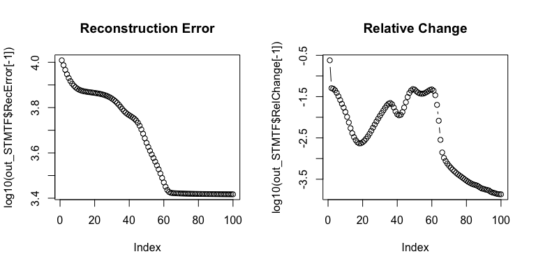

```r
layout(t(1:2))
plot(log10(out_STMTF$RecError[-1]), type="b", main="Reconstruction Error")
plot(log10(out_STMTF$RelChange[-1]), type="b", main="Relative Change")
```

The product of $U$, $S$, and $V$ shows that the original data is well-recovered by `dNMTF`.

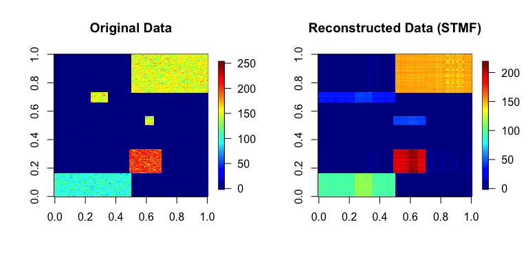

```r
recX <- out_STMTF$U %*%  out_STMTF$S %*% t(out_STMTF$V)
layout(t(1:2))
image.plot(X2, main="Original Data", legend.mar=8)
image.plot(recX, main="Reconstructed Data (STMF)", legend.mar=8)
```

The histograms of $U$, $S$, and $V$ show that $U$ looks ternary but $S$ and $V$ do not.

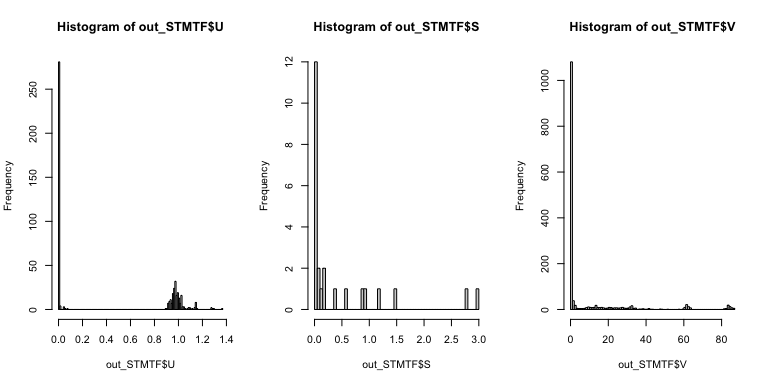

```r
layout(t(1:3))
hist(out_STMTF$U, breaks=100)
hist(out_STMTF$S, breaks=100)
hist(out_STMTF$V, breaks=100)
```

# References

Copar, A. et al. e2019. “Fast Optimization of Non-Negative Matrix Tri-Factorization: Supporting Information.” *PLOE ONE* 14(6) (e2019): e0217994.

Ding, C. et al. 2006. “Orthogonal Nonnegative Matrix Tri-Factorizations for Clustering.” *SIGKDD’06*, 126–35.

Long, B. et al. 2005. “Co-Clustering by Block Value Decomposition.” *SIGKDD’05*, 635–40.

Zhang, Z. et al. 2007. “Binary Matrix Factorization with Applications.” *ICDM 2007*, 391–400.